# STA100 Lab5

Po

4/27/2021

# Panda Village

[figure not shown]

1. Po visits the Panda Village. He captures **10 pandas** and marks their butts with paint.
2. A week later he returns to the village and captures **15 pandas**. **Five of these 15 pandas** have paint on their butts, indicating that they are recaptured pandas.
3. Can you guess/estimate the **total numbers of pandas** in the Panda Village?

   Poll:
   - $N=20$ 🐼
   - $N=30$ 🐼
   - $N=40$ 🐼

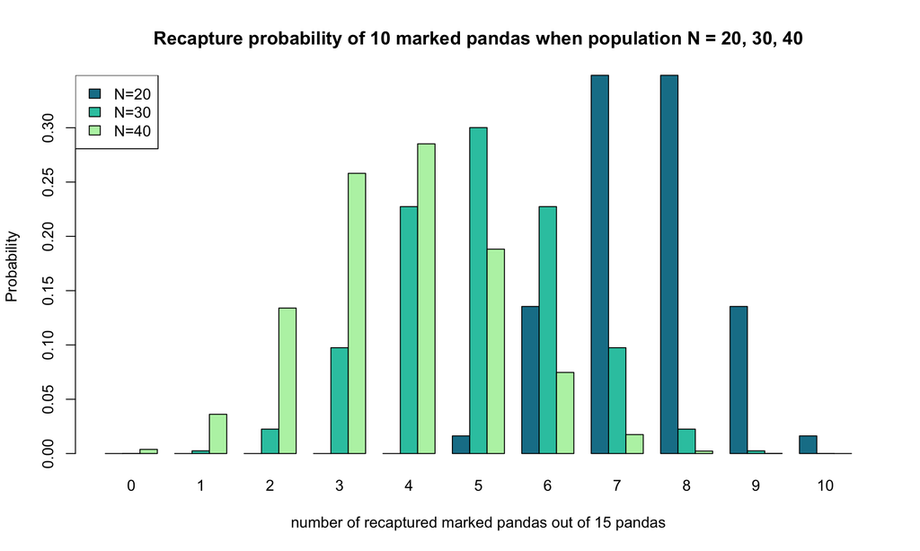

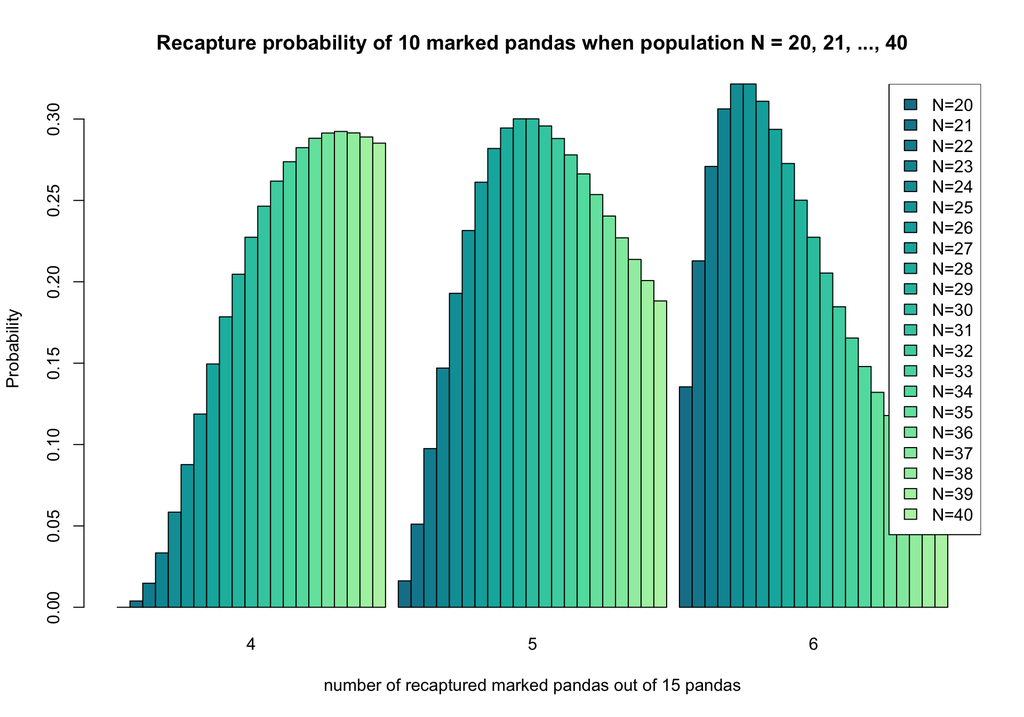

Based on maximum likelihoodk, what N would you pick if you recapture 4, 5 or 6 pandas?

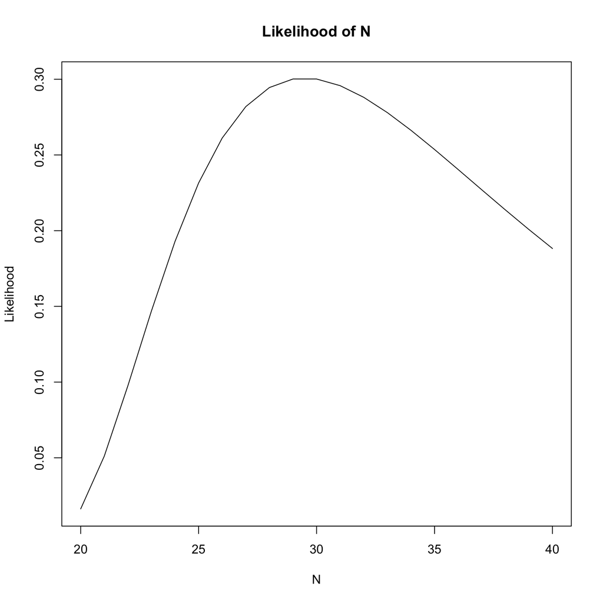

```r
hyperLik <- function(N,M,n,m){dhyper(m,M,N-M,n)}
possibleN <- 20:40
likelihoods <- hyperLik(possibleN, 10, 15, 5)
plot(possibleN,likelihoods,
     type="l",
     ylab="Likelihood",
     xlab="N",
     main = "Likelihood of N")
```

For more information aobut **Mark and recapture**, you may read [Wikipedia: Mark and recapture](https://en.wikipedia.org/wiki/Mark_and_recapture).

# Lab Assignment 3 (Lab projects?)

[figure not shown]

   set by Po.
4. Run/add/edit/delete the codes in your own copy of `LabAssignment3_jp.Rmd` and add/edit/delete some writings. Knit to see how the .pdf looks like. Tidy up the codes and writings. Knit and submit!

### Help/Documentation

Read the R Documentation of the functions you learn today. Enter the following codes, one by one, and read the corresponding documentation/help in the **Help** tab.

```r
?dhyper
```

```r
?plot
```

```r
?which.max
```

```r
?read.table
```

```r
?c
```

```r
?head
```

```r
?mean
```

```r
?sd
```

```r
?summary
```

```r
?hist
```

```r
?table
```

```r
?mosaicplot
```

```r
?boxplot
```

```r
?aggregate
```

How Po knows all those built-in functions in R?

- Way 1: Google it
- Way 2: Read R Help/Documentation

> There is no secret ingredient. – Mr. Ping 🍜

# R tutorials that help you survive in Panda Village 🎍

- Interactive R course lessons **swirl** https://swirlstats.com/students.html

  Install **swirl** with the following commands.

  ```r
  # If you haven't installed the swirl package yet
  install.packages("swirl")
  library(swirl)
  install_course_github("swirldev", "R_Programming_E")
  ```

  After **swirl** is installed (you only need to do it once), you can start/resume the R tutorial with the commands:

  ```r
  library(swirl)
  swirl()
  ```

  Schedule some time to go though all the lessons by yourself! Almost all of the R codes you need to know are here in those lessons.
- If you prefer more static readings (Po did read them to learn R!):
  - R for Beginners https://cran.r-project.org/doc/contrib/Paradis-rdebuts_en.pdf
  - An Introduction to R https://cran.r-project.org/doc/manuals/r-release/R-intro.pdf
- If you like RStudio’s data science things,
  - R for Data Science https://r4ds.had.co.nz/
  - RStudio Primer https://rstudio.cloud/learn/primers/